# Week 13 · Read model claims against their evidence

MATH 346 course companion · Regression, baselines and diagnostics

**Note**

Use this chapter with the [companion reading guide](https://lnajman.github.io/math346/companion/how-to-use.html). **Nothing in this chapter is collected or graded.** The approved syllabus, workload guide and Blackboard remain authoritative.

## Your route

**What does a fitted regression model claim, and which evidence could weaken it?**

We use the familiar `airquality` data to fit ozone on temperature, compare its training error with a simple baseline, then add wind and investigate what the model missed. Reading a coefficient correctly matters as much as obtaining it. A fluent explanation, including an LLM-generated explanation, needs evidence for each sentence.

Before you start · Words used here · Setup · Meeting 1 · Meeting 2 · AI audit · Practice and resources.

**TipA first 30-minute session**

Choose a stopping point within about 30 minutes and resume later. This is an untested stopping budget, not a completion promise.

1. Check prerequisites and setup; resolve access first if blocked.
2. Try the row-accounting prediction and read the modeling-table check.
3. Read the temperature coefficient and mean-baseline comparison; state what they describe and which observations they use.
4. Inspect the diagnostic flag explanation, then choose the next Core step.

Read displayed results when jumping ahead; run the code in order when returning to your script. The full route is Core **1, 2, 3, 4, 6, 8**, selective Guided **5, 7, 9, 10**, with **no Extension exercises** in this set. Reading and the selected lab/exercises share the **90–120-minute ordinary-week practice budget**. Use the announced reduced selection when an assessment displaces teaching time. The two class meetings retain 75 minutes each and their final five-minute exits. Meeting 2 includes Quiz 4; its modeling activities use the remaining class time.

**NoteQuiz 4 this week**

**Monday–Wednesday section: Wednesday 18 November 2026.** **Tuesday–Thursday section: Thursday 19 November 2026.**

The individual paper quiz takes **15 minutes** during regular class and covers **R Weeks 10–12**, using earlier R fundamentals where needed. It has six one-mark MCQs and three two-mark written questions, **12 marks** total, with partial credit for written responses and no negative marking. MATLAB and new Week 13 modeling are excluded.

Use the [student guide](https://lnajman.github.io/math346/assessments/quiz-04.html) and [separate practice quiz](https://lnajman.github.io/math346/assessments/quiz-04-practice.html). Bring a pen and student ID; follow Blackboard for permitted references and individual arrangements. No live quiz questions or answers appear here.

### Before you start

You should be able to open and run an R script, read a pipe, identify a table’s row meaning, handle `NA` explicitly and understand a function with a checked input/output contract. Review [Week 11](https://lnajman.github.io/math346/companion/week-11.html) for contracts and [Week 12](https://lnajman.github.io/math346/companion/week-12.html) for complete result records. No regression command syntax is assumed.

Slides provide lecture flow, this chapter explains and checks it, and the selected lab/exercises provide practice. Week 13 fits and diagnoses a few declared models; repeated modeling across groups/formulas belongs to Week 14.

**NoteWords used in this chapter**

| Word or pattern | Meaning here |
| --- | --- |
| **Response / predictor** | The variable being modeled / a variable used to describe its average relationship. |
| **Formula** | In `y ~ x`, model response `y` using predictor `x`; reversing them changes the question. |
| **Complete case** | A row with observed values for every variable required by the declared model. |
| **Coefficient / slope / intercept** | Numbers defining the fitted line; the slope is change per predictor unit, the intercept its value at predictor zero. |
| **Fitted value / residual** | The model’s estimate on a modeling row / observed response minus that estimate. |
| **Baseline** | A simple comparison rule: predict the same training mean for every row. |
| **Training RMSE** | Square root of mean squared prediction errors on the rows used for fitting, in response units. |
| **R-squared** | The fraction of response variation accounted for by the fitted relationship on its modeling rows. |
| **Standardized residual** | A residual scaled to make unusually large discrepancies easier to screen. |
| **Cook’s distance** | A measure of how much a row affects the fitted model; it is not a probability of error. |
| **Conditional coefficient** | A slope interpreted while holding the other included predictor fixed. |
| **Extrapolation / validation** | Predict beyond observed conditions / assess a declared model on data not used to fit it. |

### Read / Explain / Check / Interpret

Read the variables and formula; explain a prediction; check a specific claim; interpret with units, population and limitations. Think first; write a private comment only where requested—see the [prediction guide](https://lnajman.github.io/math346/companion/how-to-use.html#read-explain-check-interpret).

## Setup

Use R 4.1 or later and the course `dplyr` and `ggplot2` packages. Download the model starter and diagnostic starter, and save them in a `week13/` folder. The built-in `airquality` table needs no CSV download. The AI critique script is used only for selected Guided 10 work; no AI account or live call is needed.

Run this check from your `week13/` folder:

```r
required_files <- c("week13-simple-linear-model.R", "week13-model-diagnostics.R")
```

```r
missing_files <- required_files[!file.exists(required_files)]
missing_packages <- c("dplyr", "ggplot2")[!vapply(
  c("dplyr", "ggplot2"), requireNamespace, logical(1), quietly = TRUE
)]
if (length(missing_files) + length(missing_packages) == 0) {
  cat("Setup OK\n")
} else {
  cat("Missing files:", paste(missing_files, collapse = ", "), "\n")
  cat("Missing packages:", paste(missing_packages, collapse = ", "), "\n")
}
```

**Example output when both files and packages are available:**

```
Setup OK
```

This example cannot confirm your computer’s setup. Run the check yourself; use `getwd()` for a missing path and the [software checks](https://lnajman.github.io/math346/resources/software-requirements.html) for package/access help. Restart R, then run the chapter’s code in order, including the code inside the reference reveals.

Each full reference rebuilds its own `model_data` and `rmse` function. They are independent supplied scripts; keep them as separate saved files. Running this chapter in order deliberately replaces those objects when the next reference begins. Keep the simple-model output before moving to the diagnostics script.

## Meeting 1 · State what the fitted line describes

**Slide cues:** “Modeling Contract”, “Observational Question”, “Build The Modeling Table” and “Account For Exclusions”.

### Choose the rows before fitting

One source row is one recorded day in New York from May through September 1973. The response is ozone in ppb; temperature is in degrees Fahrenheit and wind is in miles per hour. We ask about an **observational association**, not what an intervention changing temperature would cause.

**Predict in a private comment first:** `airquality` has 153 rows and 37 missing `Ozone` values. Temperature and wind are complete. How many complete rows can both models use? Does keeping every retained row once show that the omitted days are representative of the others?

**Compare the row reasoning**

Both models use the same 116 rows; 37 are excluded because ozone is missing. Row accounting records the selection but does not establish representativeness. **If your answer differed,** you may have confused missing cells with missing rows or treated a consistent count as evidence about omitted days.

For Core 1/2, state the contract and attempt the table in your starter before running this check. `observation_id` is created **before** filtering so it still points to the original source row.

```r
library(dplyr)
model_rows <- airquality |>
  transmute(observation_id = row_number(), ozone_ppb = Ozone,
            temperature_f = Temp, wind_mph = Wind) |>
  filter(complete.cases(ozone_ppb, temperature_f, wind_mph))
stopifnot(
  nrow(airquality) == 153,
  sum(is.na(airquality$Ozone)) == 37,
  !anyNA(airquality$Temp), !anyNA(airquality$Wind),
  nrow(model_rows) == 116, !anyNA(model_rows),
  n_distinct(model_rows$observation_id) == 116
)
data.frame(original = nrow(airquality), retained = nrow(model_rows),
           excluded = nrow(airquality) - nrow(model_rows))
```

```
  original retained excluded
1      153      116       37
```

A silent `stopifnot` means its conditions passed; an error identifies the failed condition. Check the named input before changing a failed assertion.

### Read the formula, then the implementation

**Slide cues:** “Plot Before Fitting”, “Read The Formula”, “Fitted Equation”, “Interpret The Slope”, “Intercept Warning”, “Fitted Plus Residual”, “Preserve Row Alignment” and “Check The Alignment”.

For Core 3, read `ozone_ppb ~ temperature_f` as “model mean ozone using temperature.” `~` declares a formula; it is not an assignment. `lm` estimates a line from the declared modeling rows. `coef` returns its intercept and slope. Reversing the formula models temperature instead and changes both units and question.

For Core 4/6, write one slope sentence and name the comparison baseline in your starter before opening the complete reference. Trace the formula, then the fitted/residual columns, then each argument to `rmse`.

**Reference version · Simple model and training baseline**

```r
# MATH 346 - possible worked solution
# Compare only after attempting the starter; other correct implementations are possible.

library(dplyr)
library(ggplot2)

model_data <- airquality |>
  transmute(
    observation_id = row_number(),
    ozone_ppb = Ozone,
    temperature_f = Temp
  ) |>
  filter(complete.cases(ozone_ppb, temperature_f))

stopifnot(
  nrow(model_data) == 116,
  identical(range(model_data$temperature_f), c(57L, 97L)),
  !anyNA(model_data)
)

relationship_plot <- ggplot(
  model_data,
  aes(x = temperature_f, y = ozone_ppb)
) +
  geom_point(alpha = 0.65) +
  geom_smooth(method = "lm", se = FALSE) +
  labs(
    x = "Temperature (degrees F)",
    y = "Ozone (ppb)"
  )

relationship_build <- ggplot_build(relationship_plot)
stopifnot(nrow(relationship_build$data[[1]]) == nrow(model_data))

ozone_fit <- lm(ozone_ppb ~ temperature_f, data = model_data)

model_data <- model_data |>
  mutate(
    fitted_ozone_ppb = fitted(ozone_fit),
    residual_ppb = residuals(ozone_fit)
  )

rmse <- function(observed, predicted) {
  stopifnot(
    is.numeric(observed),
    is.numeric(predicted),
    length(observed) == length(predicted),
    !anyNA(observed),
    !anyNA(predicted)
  )

  sqrt(mean((observed - predicted)^2))
}

baseline_prediction <- mean(model_data$ozone_ppb)
baseline_rmse <- rmse(
  model_data$ozone_ppb,
  rep(baseline_prediction, nrow(model_data))
)
model_rmse <- rmse(
  model_data$ozone_ppb,
  model_data$fitted_ozone_ppb
)

coefficients <- coef(ozone_fit)
model_r_squared <- summary(ozone_fit)$r.squared

stopifnot(
  abs(coefficients[["(Intercept)"]] - (-146.995491)) < 1e-6,
  abs(coefficients[["temperature_f"]] - 2.428703) < 1e-6,
  abs(model_r_squared - 0.4877072) < 1e-6,
  abs(mean(model_data$residual_ppb)) < 1e-12,
  model_rmse < baseline_rmse
)

prediction_inputs <- tibble(temperature_f = c(70, 80, 90))
prediction_outputs <- prediction_inputs |>
  mutate(predicted_ozone_ppb = predict(ozone_fit, newdata = prediction_inputs))

stopifnot(
  nrow(prediction_outputs) == 3,
  all(prediction_outputs$temperature_f >= min(model_data$temperature_f)),
  all(prediction_outputs$temperature_f <= max(model_data$temperature_f))
)

model_summary <- tibble(
  quantity = c(
    "observations used",
    "temperature slope (ppb per degree F)",
    "R-squared",
    "baseline training RMSE (ppb)",
    "model training RMSE (ppb)"
  ),
  value = c(
    nrow(model_data),
    coefficients[["temperature_f"]],
    model_r_squared,
    baseline_rmse,
    model_rmse
  )
)

print(model_summary)
```

```
# A tibble: 5 × 2
  quantity                               value
  <chr>                                  <dbl>
1 observations used                    116
2 temperature slope (ppb per degree F)   2.43
3 R-squared                              0.488
4 baseline training RMSE (ppb)          32.8
5 model training RMSE (ppb)             23.5
```

```r
print(prediction_outputs)
```

```
# A tibble: 3 × 2
  temperature_f predicted_ozone_ppb
          <dbl>               <dbl>
1            70                23.0
2            80                47.3
3            90                71.6
```

```r
cat("Week 13 simple-linear-model checks passed.\n")
```

```
Week 13 simple-linear-model checks passed.
```

The printed summary reports a slope near **2.428703 ppb per degree F**, an R-squared near **0.487707**, and training RMSEs near **32.8 ppb** for the mean baseline and **23.5 ppb** for the line. The reference prediction inputs 70, 80 and 90 F lie inside the observed 57–97 F range; making these predictions is not a new-data accuracy test because no observed responses are evaluated for them.

**Predict · Think first:** the intercept is about -147.0. Is it an observed negative ozone value? What does a positive residual mean?

**Compare coefficients and residuals**

The intercept is the fitted line at 0 F, outside these modeling temperatures; it is not a negative measurement in the table. A positive residual means the observed ozone exceeds its fitted value. **If your answer differed,** distinguish the fitted line from source measurements and read residual as observed minus fitted, not the reverse.

The slope describes an estimated change in **mean ozone associated with** a one-degree difference within these conditions. It does not describe every day’s change or establish causation.

### A complete claim and its evidence

“A one-degree-F higher temperature is associated with about 2.43 ppb higher fitted mean ozone in these observed conditions” states a model claim with units. The positive fitted slope supports it. The observational design does not support replacing “is associated with” by “causes.” Other properly justified claim pairs are possible; this is one example, not a required sentence to memorise.

Naming units or saying “check linearity” supplies useful context, but does not by itself state a claim and explain its evidence. A complete answer identifies what the fitted output supports and why a proposed stronger statement goes beyond that evidence.

Successfully fitting a line also does not establish that a linear description is adequate. `lm` can return coefficients while residuals still show curvature, uneven spread or influential observations. Residual checks investigate what the model missed; untouched new-data evaluation addresses predictive performance. Keep those two questions separate from whether the code ran successfully.

The reference checks how many points reached the scatter layer. View it and check row alignment independently. These checks use the reference object names; run the modeling-table check and reference above first. If your completed starter uses other names, adapt the names in these checks:

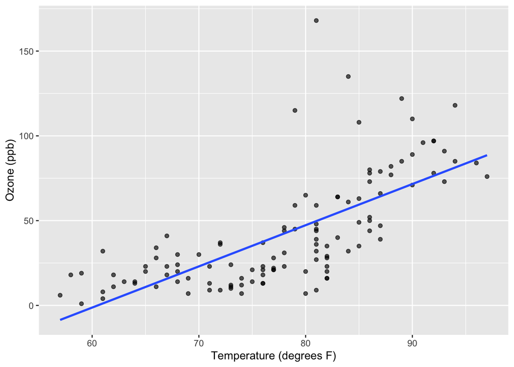

```r
print(relationship_plot)
```

```r
stopifnot(
  identical(model_data$observation_id, model_rows$observation_id),
  length(fitted(ozone_fit)) == nrow(model_data),
  length(residuals(ozone_fit)) == nrow(model_data),
  max(abs(model_data$ozone_ppb -
          (model_data$fitted_ozone_ppb + model_data$residual_ppb))) < 1e-12,
  abs(rmse(c(0, 2), c(1, 1)) - 1) < 1e-12
)
```

For the last check, the two prediction errors are -1 and 1. Squaring gives 1 and 1; their mean and its square root are 1. That known answer checks the RMSE calculation independently. The reconstruction identity checks numerical consistency; retain source IDs and unchanged row order to establish which days the values describe. Neither check proves the model describes the pattern well.

### Compare like with like

**Slide cues:** “Mean Baseline”, “Fair Training Comparison”, “Training Is Not Validation”, “R-Squared: Baseline Formula” and “R-Squared: Interpretation And Limits”.

The mean baseline repeats one number for every training row. The line changes its fitted value with temperature. Both RMSEs must use the **same response, same 116 rows and same units**. Lower RMSE means smaller squared discrepancies on that comparison, not “more observations predicted exactly.”

### R-squared compares squared errors with the mean baseline

For the unweighted least-squares fits **with an intercept** used here, and a response that is not constant,

$$R^2 = 1 -
\frac{\sum_i (y_i-\widehat y_i)^2}
{\sum_i (y_i-\bar y)^2}.$$

Here $y_i$ is observed ozone, $\widehat y_i$ is its fitted value and $\bar y$ is the mean ozone on the **same training rows**. The numerator is the fitted model’s total squared errors. The denominator is the total squared errors from giving every row the training-mean prediction. Both sums use the same observations and have the same squared units, so their ratio and $R^2$ have no units. This mean-baseline interpretation is specific to the intercept models here; do not silently apply it to a no-intercept fit or a different evaluation dataset.

For the simple temperature model, $R^2\approx0.488$ says that the fitted line’s training sum of squared errors is about **48.8% lower** than that of the mean baseline. Equivalently, about 48.8% of the response variation around the training mean is accounted for by this fitted relationship. This does not mean 48.8% of days are predicted correctly, 48.8% lower RMSE, or a causal effect. Because RMSE takes a square root, its percentage reduction is different. New-data performance still requires new-data evidence.

For an arithmetic illustration, if the mean baseline’s squared-error total were 100 and the line’s were 51.2, the formula would give $1-51.2/100=0.488$. These are illustrative totals, not additional measurements from `airquality`. In R, `summary(ozone_fit)$r.squared` returns the simple model’s value. Use unrounded model outputs when checking it.

**Predict in a private comment first:** after seeing 23.5 versus 32.8 ppb, can you say the line predicts a new summer’s days well? Does R-squared about 0.488 mean 48.8% of these days were predicted correctly?

**Compare what the metrics support**

The line fits these training rows better than the mean baseline. No new days were assessed. R-squared describes response variation accounted for by the fitted relationship on these rows; it is not a classification accuracy rate. **If your answer differed,** you may have mistaken fitting evidence for validation evidence or read “fraction of variation” as “fraction of days.”

**Individual in-class exit, final five minutes:** for the ozone-on-temperature model, write one supported claim and one unsupported claim. Explain why for each and include units where relevant. Write a short individual response in your own words; code is not required. Follow the announced classroom route.

**Self-check (no submission):** a report compares a model’s RMSE on 116 complete rows with a baseline computed on a different subset of 100 rows. Both numbers are in ppb. What must be fixed before interpreting their difference?

**Compare the Meeting 1 self-check**

Recompute both predictions and RMSEs on one declared set of rows with the same response. Equal units alone do not make different populations comparable. Then label the comparison training or new-data evaluation according to where the model was fitted and assessed.

## Meeting 2 · Investigate what remains

**Slide cues:** “Meeting 2 Question”, “Meeting 2 Setup”, “Add Wind”, “Conditional Coefficients”, “Save Aligned Predictions And Residuals”, “Residual Plot”, “Look For Structure”, “Standardized Residuals”, “Cook’s Distance”, “Diagnostic Flags Ask Questions” and “Same-Row Comparison”.

### Rebuild the declared additive model

Resuming here? The complete reference and following diagnostic check can run together in a fresh session; no saved Meeting 1 model object is needed.

The second reference builds a table containing ozone, temperature **and wind**, then fits both formulas on it. Because wind has no missing values here, its 116 source IDs agree with the earlier simple-model table. In another dataset, adding a predictor could change the complete-case population; check IDs, not just counts, before comparing fits.

`temperature_f + wind_mph` includes both predictors. A temperature slope now compares fitted means at the **same wind speed**; the wind slope holds temperature fixed. These remain adjusted associations. The formula adds no interaction term, so its temperature slope does not change with wind.

For Core 8, locate the additive formula, the diagnostic columns and the flag conditions in your starter before opening the reference. Trace the model fit, then its residuals, Cook’s distances and plot in that order.

**Reference version · Additive model and diagnostic flags**

```r
# MATH 346 - possible worked solution
# Compare only after attempting the starter; other correct implementations are possible.

library(dplyr)
library(ggplot2)

model_data <- airquality |>
  transmute(
    observation_id = row_number(),
    ozone_ppb = Ozone,
    temperature_f = Temp,
    wind_mph = Wind
  ) |>
  filter(complete.cases(ozone_ppb, temperature_f, wind_mph))

stopifnot(nrow(model_data) == 116, !anyNA(model_data))

simple_fit <- lm(
  ozone_ppb ~ temperature_f,
  data = model_data
)
additive_fit <- lm(
  ozone_ppb ~ temperature_f + wind_mph,
  data = model_data
)

model_data <- model_data |>
  mutate(
    simple_prediction = predict(simple_fit),
    additive_prediction = predict(additive_fit),
    additive_residual = residuals(additive_fit),
    standardized_residual = rstandard(additive_fit),
    cooks_distance = cooks.distance(additive_fit)
  )

rmse <- function(observed, predicted) {
  stopifnot(length(observed) == length(predicted), !anyNA(observed), !anyNA(predicted))
  sqrt(mean((observed - predicted)^2))
}

baseline_prediction <- mean(model_data$ozone_ppb)
comparison <- tibble(
  model = c("mean baseline", "temperature", "temperature + wind"),
  training_rmse_ppb = c(
    rmse(model_data$ozone_ppb, rep(baseline_prediction, nrow(model_data))),
    rmse(model_data$ozone_ppb, model_data$simple_prediction),
    rmse(model_data$ozone_ppb, model_data$additive_prediction)
  ),
  r_squared = c(
    NA_real_,
    summary(simple_fit)$r.squared,
    summary(additive_fit)$r.squared
  )
)

residual_plot <- ggplot(
  model_data,
  aes(x = additive_prediction, y = additive_residual)
) +
  geom_hline(yintercept = 0, linetype = "dashed") +
  geom_point(alpha = 0.65) +
  labs(
    x = "Fitted ozone (ppb)",
    y = "Residual (ppb)"
  )

residual_build <- ggplot_build(residual_plot)
stopifnot(nrow(residual_build$data[[2]]) == nrow(model_data))

influence_threshold <- 4 / nrow(model_data)
flagged <- model_data |>
  filter(
    abs(standardized_residual) > 2 |
      cooks_distance > influence_threshold
  ) |>
  arrange(desc(cooks_distance))

additive_coefficients <- coef(additive_fit)

stopifnot(
  abs(additive_coefficients[["temperature_f"]] - 1.840179) < 1e-6,
  abs(additive_coefficients[["wind_mph"]] - (-3.055491)) < 1e-6,
  abs(summary(additive_fit)$r.squared - 0.5687097) < 1e-6,
  abs(mean(model_data$additive_residual)) < 1e-12,
  comparison$training_rmse_ppb[[3]] < comparison$training_rmse_ppb[[2]],
  comparison$training_rmse_ppb[[2]] < comparison$training_rmse_ppb[[1]],
  sum(model_data$cooks_distance > influence_threshold) == 7,
  sum(abs(model_data$standardized_residual) > 2) == 4,
  flagged$observation_id[[1]] == 117
)

print(comparison)
```

```
# A tibble: 3 × 3
  model              training_rmse_ppb r_squared
  <chr>                          <dbl>     <dbl>
1 mean baseline                   32.8    NA
2 temperature                     23.5     0.488
3 temperature + wind              21.6     0.569
```

```r
print(flagged)
```

```
  observation_id ozone_ppb temperature_f wind_mph simple_prediction
1            117       168            81      3.4         49.729477
2             48        37            72     20.7         27.871147
3             62       135            84      4.1         57.015587
4             30       115            79      5.7         44.872070
5              9         8            61     20.1          1.155411
6             18         6            57     18.4         -8.559403
7             99       122            89      4.0         69.159103
8             86       108            85      8.0         59.444290
  additive_prediction additive_residual standardized_residual cooks_distance
1           67.632594         100.36741              4.690040     0.31495719
2           -1.789009          38.78901              1.869535     0.12763493
3           71.014287          63.98571              2.975109     0.09622296
4           56.924608          58.07539              2.688514     0.05690719
5          -20.197681          28.19768              1.345960     0.05330163
6          -22.364061          28.36406              1.345443     0.04508134
7           80.520730          41.47927              1.930376     0.04282151
8           60.938051          47.06195              2.168343     0.02185484
```

```r
cat("Week 13 diagnostic flags are prompts for investigation, not automatic deletion rules.\n")
```

```
Week 13 diagnostic flags are prompts for investigation, not automatic deletion rules.
```

```r
cat("Week 13 model-diagnostic checks passed.\n")
```

```
Week 13 model-diagnostic checks passed.
```

These checks use the object names from the reference above. Run that reference first; if your completed starter uses other names, adapt them in these checks.

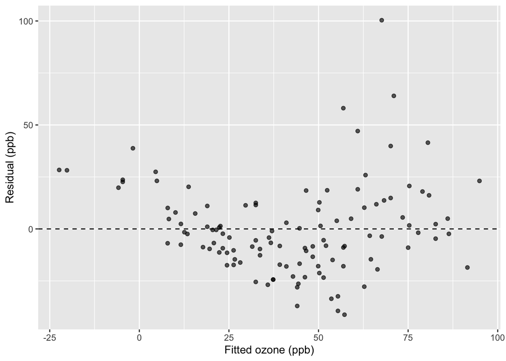

```r
print(residual_plot)
```

```r
expected_model_ids <- which(complete.cases(airquality[c("Ozone", "Temp", "Wind")]))
stopifnot(
  identical(model_data$observation_id, expected_model_ids),
  max(abs(model_data$ozone_ppb -
          (model_data$additive_prediction + model_data$additive_residual))) < 1e-12
)
data.frame(
  model = "temperature + wind",
  large_standardized_residuals = sum(abs(model_data$standardized_residual) > 2),
  cooks_flags = sum(model_data$cooks_distance > influence_threshold),
  either_flag = nrow(flagged)
)
```

```
               model large_standardized_residuals cooks_flags either_flag
1 temperature + wind                            4           7           8
```

Read the residual plot as fitted ozone horizontally and **observed minus fitted ozone** vertically, both in ppb. The dashed horizontal line is zero. Points above it were underpredicted. Look for bends, changes in vertical spread, clusters and isolated points. A near-zero mean residual can coexist with those patterns; with an intercept it is a fitted-model algebraic property, not a complete diagnostic pass. Some fitted values are negative here: these are model estimates, not negative recorded ozone measurements. That is a limitation to inspect in this unconstrained linear model.

The additive temperature slope is about **1.840179 ppb per degree F** and the wind slope about **-3.055491 ppb per mph**. These answer a different, conditional question from the simple model’s 2.428703. Its training RMSE is about **21.6 ppb**, with R-squared about **0.568710**. Added predictors can improve training fit; new-data evidence is still missing.

The “R-Squared Reminder” slide reuses the baseline definition introduced in Meeting 1; it does not introduce a different statistic. Both models use the same training days and mean-baseline denominator, so the additive model’s higher R-squared means a lower training squared-error total. It does not establish better prediction on unseen days.

### Flags invite questions, not automatic deletion

**Cook’s distance asks how much one observation influences the fitted model.** Imagine fitting the same formula to all training observations, then refitting after leaving out one particular observation. Compare the two sets of fitted values at the original predictor inputs. Cook’s distance summarises that overall change on a scaled basis. A large value means that the observation has a comparatively strong effect on the fitted relationship.

A **residual** measures a discrepancy for one observation: observed minus fitted. **Cook’s distance** measures influence on the model. They answer different questions. An observation at an unusual predictor value can pull the fit towards itself, so influence cannot be judged from residual size alone. A genuine observation can be influential; influence does not establish a measurement error.

`cooks.distance(additive_fit)` computes one Cook’s-distance value per modeling row. You should be able to explain its meaning, read the output and justify a follow-up investigation. **No Cook’s-distance formula, derivation or hand calculation is required for this lesson.** Consult R’s `?influence.measures` and `?summary.lm` help for the diagnostic and R-squared definitions.

For this **additive model**, four residuals exceed 2 in absolute standardized units and seven Cook’s distances exceed `4/116`, about 0.0345. `abs` checks both negative and positive residuals. Cook’s distance measures influence, not whether a measurement is false. The script’s `|` selects a row meeting **either** condition; a row meeting both still appears once.

The classroom rule `4 / nrow(model_data)` is a **screening threshold**, not a universal decision rule, a probability that the row is incorrect or an instruction to delete it. Here it is $4/116\approx0.0345$. Inspect the original record and context, then assess whether a transparently documented sensitivity comparison changes the conclusion. Retain valid observations unless a defensible, stated analysis decision justifies otherwise.

**Predict · Think first:** must the combined flag table contain 4 + 7 = 11 rows? Does crossing the Cook’s threshold justify removing a row immediately?

**Compare the flag logic**

The groups can overlap, so add their counts only after accounting for overlap. Read `either_flag` above and compare the source IDs in `flagged`. No threshold alone justifies deletion. **If your answer differed,** you may have counted memberships rather than distinct rows, or treated a screening rule as proof that a value is wrong.

The reference sorts flagged rows by Cook’s distance; the first is original **observation 117**, not “the 117th retained row” (there are only 116 retained rows). Use `observation_id` to recover the source day. Ask whether its measurement is valid, whether unusual weather/context is real, and how much the fitted conclusion depends on it. Do not remove it just to improve a metric. Repeating whole modeling workflows is next week’s topic.

## Guided audit · A fluent explanation is a set of claims

**Slide cues:** “AI Claim Audit” and “Do Not Declare A Winner Yet”.

Use this section selectively for **Guided 10**; the full AI-review lab is not an additional required lab. The candidate is supplied locally; no external AI call is involved.

> “Increasing temperature by one degree causes ozone to rise by 2.43 ppb. The intercept predicts ozone at 0 F. An R-squared of 0.49 means 49% of observations are predicted correctly. The low training error proves the model will predict new days well, and the residuals show no unusual observations.”

Before revealing the audit, choose evidence for each claim:

| Candidate claim | Evidence to inspect first |
| --- | --- |
| “causes” | How the data were collected; a fitted number alone cannot settle this |
| meaningful prediction at 0 F | Observed temperature range |
| percent predicted correctly | What R-squared measures |
| good new-day predictions | Which rows trained the model and which rows were evaluated |
| no unusual observations | Residual/influence output for the specified model |

**Predict in a private comment first:** select one sentence, name the exact output or design fact you would check, then write a defensible replacement. A grammatically correct sentence or a passing R script is not enough.

**Compare the evidence and run the supplied audit**

```r
library(dplyr)

model_data <- airquality |>
  transmute(
    observation_id = row_number(),
    ozone_ppb = Ozone,
    temperature_f = Temp
  ) |>
  filter(complete.cases(ozone_ppb, temperature_f))

ozone_fit <- lm(ozone_ppb ~ temperature_f, data = model_data)

generated_interpretation <- paste(
  "Increasing temperature by one degree causes ozone to rise by",
  "2.43 ppb. The intercept predicts ozone at 0 F.",
  "An R-squared of 0.49 means 49% of observations are predicted correctly.",
  "The low training error proves the model will predict new days well,",
  "and the residuals show no unusual observations."
)

coefficients <- coef(ozone_fit)
r_squared <- summary(ozone_fit)$r.squared
standardized_residuals <- rstandard(ozone_fit)
cooks_distances <- cooks.distance(ozone_fit)

rmse <- function(observed, predicted) {
  sqrt(mean((observed - predicted)^2))
}

baseline_rmse <- rmse(
  model_data$ozone_ppb,
  rep(mean(model_data$ozone_ppb), nrow(model_data))
)
training_rmse <- rmse(model_data$ozone_ppb, predict(ozone_fit))

audit <- tibble(
  generated_claim = c(
    "temperature causes ozone to rise",
    "the intercept is a meaningful prediction at 0 F",
    "R-squared is the percentage predicted correctly",
    "training error proves performance on new days",
    "there are no unusual observations"
  ),
  verdict = rep("unsupported or incorrect", 5),
  evidence = c(
    "the fitted observational association does not establish causation",
    paste("observed temperatures range from", min(model_data$temperature_f),
          "to", max(model_data$temperature_f), "F"),
    "R-squared describes variation accounted for by the fitted model",
    "training predictions reuse the same observations used for fitting",
    paste(sum(abs(standardized_residuals) > 2),
          "standardized residuals exceed 2 in absolute value")
  )
)

stopifnot(
  nrow(model_data) == 116,
  abs(coefficients[["temperature_f"]] - 2.428703) < 1e-6,
  min(model_data$temperature_f) == 57,
  max(model_data$temperature_f) == 97,
  abs(r_squared - 0.4877072) < 1e-6,
  training_rmse < baseline_rmse,
  sum(abs(standardized_residuals) > 2) == 5,
  sum(cooks_distances > 4 / nrow(model_data)) == 5,
  nrow(audit) == 5
)

cat(generated_interpretation, "\n\n")
```

```
Increasing temperature by one degree causes ozone to rise by 2.43 ppb. The intercept predicts ozone at 0 F. An R-squared of 0.49 means 49% of observations are predicted correctly. The low training error proves the model will predict new days well, and the residuals show no unusual observations.
```

```r
print(audit)
```

```
# A tibble: 5 × 3
  generated_claim                                 verdict               evidence
  <chr>                                           <chr>                 <chr>
1 temperature causes ozone to rise                unsupported or incor… the fit…
2 the intercept is a meaningful prediction at 0 F unsupported or incor… observe…
3 R-squared is the percentage predicted correctly unsupported or incor… R-squar…
4 training error proves performance on new days   unsupported or incor… trainin…
5 there are no unusual observations               unsupported or incor… 5 stand…
```

```r
cat("Week 13 AI model-interpretation audit passed.\n")
```

```
Week 13 AI model-interpretation audit passed.
```

The audit is for the **temperature-only model**: it has **five** large standardized residuals and **five** Cook’s flags. Earlier counts 4/7 belong to the additive model; diagnostics depend on the model, not just the dataset. The intercept sentence is algebraically correct; using that value as a meaningful prediction for these conditions is the unsupported step. Qualify it with the observed range rather than calling the definition itself false.

A defensible interpretation says: on these 116 observed days, temperature is associated with mean ozone, with fitted slope about 2.43 ppb per degree F. The intercept is algebraically the value at 0 F, but that is outside the observed 57–97 F range. About 0.488 of response variation is accounted for on these modeling rows. Training RMSE is lower than the mean baseline, with flagged observations to investigate; no new-day performance was measured.

**If your answer differed,** you may have accepted the explanation’s confidence instead of identifying the model, units, design and evaluation rows behind it. Read all code and claims you accept from an LLM and keep the checks required by the [course AI policy](https://lnajman.github.io/math346/syllabus/ai-policy.html). Never supply private student information or assessment keys to an external tool.

**Individual in-class exit, final five minutes:** an observation exceeds the classroom Cook’s-distance threshold. Explain what this flag suggests, one concrete investigation before deciding whether to exclude the observation, and why a lower training RMSE alone would not establish better prediction on new data. Write a short individual response in your own words; code is not required. Follow the announced classroom route.

**Self-check (no submission):** a large positive residual and a Cook’s flag occur for the same day. Explain what each measures and name a useful next investigation without deciding the day is an error.

**Compare the Meeting 2 self-check**

The positive residual says observed ozone exceeded the fitted value; Cook’s distance concerns how much that row affects the fit. Inspect the original source day, measurement validity and conditions, and ask whether the conclusion depends strongly on it. Neither diagnostic establishes a data-entry mistake.

## Practice, recovery and next steps

| Work | Practice supported here |
| --- | --- |
| **Core 1, 2** | State the contract and reconcile original/retained/excluded rows |
| **Core 3, 4** | Read/reverse formulas and interpret coefficients with units and scope |
| **Core 6** | Test RMSE and compare with a mean baseline on identical rows |
| **Core 8** | Read additive diagnostics and investigate a flagged source row |
| **Guided 5, 7, 9, 10** | Residual reconstruction, R-squared explanation, model comparison and AI audit; use selectively |
| **Extension** | None in this exercise set |

The worked references support the selected main-lab checkpoints; they are not extra scripts to submit. Keep your checked work for your own use and any checkpoint explicitly requested on Blackboard.

**Possible solutions · Compare after your attempt**

- Simple-model possible solution
- Diagnostics possible solution

These are unchanged public comparison files. Other correct implementations are possible; keep checks whose purpose you can explain.

If an object is missing, rerun its defining block rather than relying on an old workspace. If counts or coefficients differ, check the formula, complete-case variables, source IDs and model before comparing numbers. If a model runs but you cannot explain it, start with one row’s observed/fitted/residual values.

**Project 2:** locate response, predictors, formula, principal coefficient, mean baseline, metric and failure condition in the approved model plan. The frozen-plan gate follows Week 13 instruction; validation files stay withheld until that gate closes and the common Week 14 release. Follow the [project instructions](https://lnajman.github.io/math346/projects/project-2-modeling.html) and [milestone map](https://lnajman.github.io/math346/projects/project-milestones.html). Training fit is not validation.

The model-plan checkpoint is due **Friday 20 November 2026, 23:55 UAE time**. Complete the frozen-plan page of the supplied template and export it as **group-NN-model-plan.pdf**, including the team number, names and student IDs. The member with the **lowest student ID** submits once in their own section’s Blackboard course, including for cross-section teams. Do not submit duplicates. No full report, code, dataset or ZIP is required at this checkpoint.

This is a formative checkpoint with no separate grade. The final project assesses the plan’s quality and implementation within the existing rubric. Consult Blackboard for feedback, requested clarification and confirmation before validation release. Identify and explain later deviations instead of silently changing the plan after inspecting validation outcomes.

**Where this fits:** [Week 13 notes](https://lnajman.github.io/math346/weeks/week-13.html) · [Slides](https://lnajman.github.io/math346/slides/week-13.html) · [Main lab](https://lnajman.github.io/math346/labs/lab-13-model-basics.html) · [AI-review lab](https://lnajman.github.io/math346/labs/lab-13-ai-model-review.html) · [Exercises](https://lnajman.github.io/math346/weeks/week-13-exercises.html).

[Published companion chapters](https://lnajman.github.io/math346/companion/index.html).